# (Explanatory Data Analysis )

## Using (Titanic Data)

## Investigation Overview

> who survived in titanic and search about parameters affected on it?

## Dataset Overview

## Parameters

> pclass: A proxy for socio-economic status (SES) 1st = Upper 2nd = Middle 3rd = Lower

> age: Age is fractional if less than 1. If the age is estimated, is it in the form of xx.5

> sibsp: The dataset defines family relations in this way... Sibling = brother, sister, stepbrother, stepsister Spouse = husband, wife (mistresses and fiancés were ignored)

> parch: The dataset defines family relations in this way... Parent = mother, father Child = daughter, son, stepdaughter, stepson Some children travelled only with a nanny, therefore parch=0 for them.

> pclass is numeric I converted it to objects to understand(1st = Upper 2nd = Middle 3rd = Lower), I extract new features (family_size) from SibSp and Parch Columns ,and extract other feature (Fare_Per_Person) from family_size and fare columns. I noticed 2 row null values in Emabrked Columns then I fill it by Mode.

## ( Univariate Exploration)

> I explore Passengers different Ages on Titanic ,I explore numbers of passenger in each class.

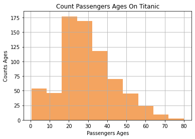

> most passengers ages are between 20 to 40 and max of age is 80

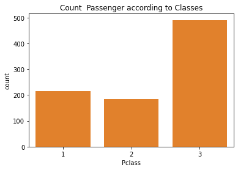

> The lower p class we found a lot of passengers compared to other classes

## Bivariate Exploration

> I explore realtionship between ages and who survived and Are the smallest age Survived than Older?

> I explore realtionship does Embarked Column affects to Survival?

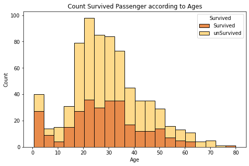

> the most passengers survive who the age in middle at age 30 and the age greater than 60 most of passengers don't survive.

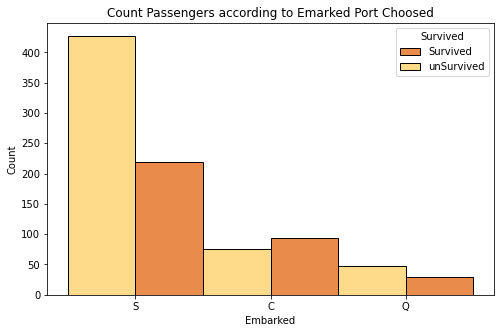

## Multivariate Exploration

Explore who survived according to gender and Family Size. Does the passenger who travels alone is survived?

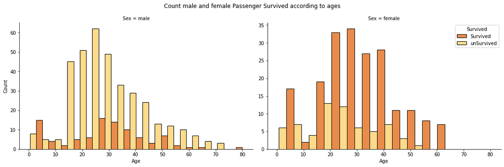

> female passengers more Survival than male in titatic

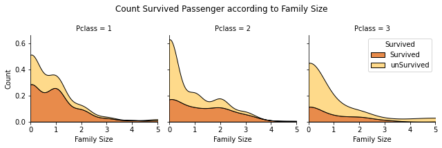

## Thank you so much for your interest and attention